# Google Capstone Project: Bike Share Speedy Success

Benedict Nyamwanga

2024-05-22

## Business Task

The business task is to understand how Cyclistic bikes are used differently by annual members and casual riders. This will enable the management design effective marketing strategies geared to converting casual riders into annual members. By analyzing Cyclistic’s historical bike trip data to identify trends and insights will help in having informed decision on how to develop a strategy for targeted marketing campaigns.

## Data Sources used

The data used for analysis is Cyclistic’s historical bike trip data which is public data from Data License Agreement | Divvy Bikes,[Data License Agreement | Divvy Bikes](https://www.divvybikes.com/data-license-agreement) which includes information such as ride ID, rideable type, start and end timestamps, start and end station details, latitude and longitude coordinates, and rider type (member or casual). The data provides insights into how customers utilize Cyclistic bikes for various purposes and durations.

## Data Preparation, Processing and Analysis Steps

### Technology used

```r
options(repos = c(CRAN = "https://cran.rstudio.com"))
```

### Data Preparation

#### Installed Required Packages

```r
install.packages("tidyverse")
install.packages("lubridate") # to work with dates
install.packages("skimr") # to skim the data
install.packages("janitor") # to claen the data
install.packages("readr") # to import the data
install.packages("dplyr")
```

```r
install.packages("ggplot2")
```

#### Loaded Packages

```r
library(tidyverse)
library(lubridate)
library(skimr)
library(janitor)
```

```r
library(readr)
library(dplyr)
library(ggplot2)
```

#### Importing Data

```r
data1 <-read_csv("E:/BJSchooling/Data Analyst/Case Studies/Capstone-1/202305-divvy-tripdata.csv")
data2 <-read_csv("E:/BJSchooling/Data Analyst/Case Studies/Capstone-1/202306-divvy-tripdata.csv")
data3 <-read_csv("E:/BJSchooling/Data Analyst/Case Studies/Capstone-1/202307-divvy-tripdata.csv")
data4 <-read_csv("E:/BJSchooling/Data Analyst/Case Studies/Capstone-1/202308-divvy-tripdata.csv")
data5 <-read_csv("E:/BJSchooling/Data Analyst/Case Studies/Capstone-1/202309-divvy-tripdata.csv")
data6 <-read_csv("E:/BJSchooling/Data Analyst/Case Studies/Capstone-1/202310-divvy-tripdata.csv")
data7 <-read_csv("E:/BJSchooling/Data Analyst/Case Studies/Capstone-1/202311-divvy-tripdata.csv")
data8 <-read_csv("E:/BJSchooling/Data Analyst/Case Studies/Capstone-1/202312-divvy-tripdata.csv")
data9 <-read_csv("E:/BJSchooling/Data Analyst/Case Studies/Capstone-1/202401-divvy-tripdata.csv")
data10 <-read_csv("E:/BJSchooling/Data Analyst/Case Studies/Capstone-1/202402-divvy-tripdata.csv")
data11 <-read_csv("E:/BJSchooling/Data Analyst/Case Studies/Capstone-1/202403-divvy-tripdata.csv")
data12 <-read_csv("E:/BJSchooling/Data Analyst/Case Studies/Capstone-1/202404-divvy-tripdata.csv")
```

### Data Processing

#### Knowing Your Data Structure

```r
glimpse(data1)
```

```
## Rows: 604,827
## Columns: 13
## $ ride_id            <chr> "0D9FA920C3062031", "92485E5FB5888ACD", "FB144B3FC8…
## $ rideable_type      <chr> "electric_bike", "electric_bike", "electric_bike", …
## $ started_at         <dttm> 2023-05-07 19:53:48, 2023-05-06 18:54:08, 2023-05-…
## $ ended_at           <dttm> 2023-05-07 19:58:32, 2023-05-06 19:03:35, 2023-05-…
## $ start_station_name <chr> "Southport Ave & Belmont Ave", "Southport Ave & Bel…
## $ start_station_id   <chr> "13229", "13229", "13162", "13196", "TA1308000047",…
## $ end_station_name   <chr> NA, NA, NA, "Damen Ave & Cortland St", "Southport A…
## $ end_station_id     <chr> NA, NA, NA, "13133", "13229", "TA1306000029", "1343…
## $ start_lat          <dbl> 41.93941, 41.93948, 41.85379, 41.89456, 41.95708, 4…
## $ start_lng          <dbl> -87.66383, -87.66385, -87.64672, -87.65345, -87.664…
## $ end_lat            <dbl> 41.93000, 41.94000, 41.86000, 41.91598, 41.93948, 4…
## $ end_lng            <dbl> -87.65000, -87.69000, -87.65000, -87.67733, -87.663…
## $ member_casual      <chr> "member", "member", "member", "member", "member", "…
```

#### Combine Data

use rbind() or bind_rows() functions to vertically combine data

```r
combined_df <- rbind(data1, data2, data3, data4, data5, data6, data7, data8, data9, data10, data11, data12)
```

#### Inspection of combined data

you can use str(), glimse(), skim_without_charts() functions

```r
skim_without_charts(combined_df)
```

Data summary

| Name | combined_df |
| --- | --- |
| Number of rows | 5738612 |
| Number of columns | 13 |
| _______________________ |  |
| Column type frequency: |  |
| character | 7 |
| numeric | 4 |
| POSIXct | 2 |
| ________________________ |  |
| Group variables | None |

**Variable type: character**

| skim_variable | n_missing | complete_rate | min | max | empty | n_unique | whitespace |
| --- | --- | --- | --- | --- | --- | --- | --- |
| ride_id | 0 | 1.00 | 16 | 16 | 0 | 5738612 | 0 |
| rideable_type | 0 | 1.00 | 11 | 13 | 0 | 3 | 0 |
| start_station_name | 885429 | 0.85 | 10 | 64 | 0 | 1630 | 0 |
| start_station_id | 885429 | 0.85 | 3 | 35 | 0 | 1584 | 0 |
| end_station_name | 939115 | 0.84 | 10 | 64 | 0 | 1645 | 0 |
| end_station_id | 939115 | 0.84 | 3 | 36 | 0 | 1595 | 0 |
| member_casual | 0 | 1.00 | 6 | 6 | 0 | 2 | 0 |

**Variable type: numeric**

| skim_variable | n_missing | complete_rate | mean | sd | p0 | p25 | p50 | p75 | p100 |
| --- | --- | --- | --- | --- | --- | --- | --- | --- | --- |
| start_lat | 0 | 1 | 41.90 | 0.05 | 41.63 | 41.88 | 41.90 | 41.93 | 42.07 |
| start_lng | 0 | 1 | -87.65 | 0.03 | -87.94 | -87.66 | -87.64 | -87.63 | -87.46 |
| end_lat | 7610 | 1 | 41.90 | 0.05 | 0.00 | 41.88 | 41.90 | 41.93 | 42.18 |
| end_lng | 7610 | 1 | -87.65 | 0.07 | -88.16 | -87.66 | -87.64 | -87.63 | 0.00 |

**Variable type: POSIXct**

| skim_variable | n_missing | complete_rate | min | max | median | n_unique |
| --- | --- | --- | --- | --- | --- | --- |
| started_at | 0 | 1 | 2023-05-01 00:00:33 | 2024-04-30 23:59:46 | 2023-09-01 11:13:33 | 4836538 |
| ended_at | 0 | 1 | 2023-05-01 00:04:28 | 2024-05-02 00:59:33 | 2023-09-01 11:35:50 | 4848215 |

#### Cleaning Data

##### Ensure naming consistency

```r
combined_df <- clean_names(combined_df)
```

##### Transforming data

###### Use mutate() function to create ride_length and day_of_week

```r
combined_df <- combined_df %>%
  mutate(
         ride_length = as.numeric(difftime(ended_at, started_at, units = "mins")),
         day_of_week = wday(started_at, label = TRUE))
```

##### Confirming the changes

```r
head(combined_df)
```

```
## # A tibble: 6 × 15
##   ride_id          rideable_type started_at          ended_at
##   <chr>            <chr>         <dttm>              <dttm>
## 1 0D9FA920C3062031 electric_bike 2023-05-07 19:53:48 2023-05-07 19:58:32
## 2 92485E5FB5888ACD electric_bike 2023-05-06 18:54:08 2023-05-06 19:03:35
## 3 FB144B3FC8300187 electric_bike 2023-05-21 00:40:21 2023-05-21 00:44:36
## 4 DDEB93BC2CE9AA77 classic_bike  2023-05-10 16:47:01 2023-05-10 16:59:52
## 5 C07B70172FC92F59 classic_bike  2023-05-09 18:30:34 2023-05-09 18:39:28
## 6 2BA66385DF8F815A classic_bike  2023-05-30 15:01:21 2023-05-30 15:17:00
## # ℹ 11 more variables: start_station_name <chr>, start_station_id <chr>,
## #   end_station_name <chr>, end_station_id <chr>, start_lat <dbl>,
## #   start_lng <dbl>, end_lat <dbl>, end_lng <dbl>, member_casual <chr>,
## #   ride_length <dbl>, day_of_week <ord>
```

### Analyse Data

#### Summary Statistics

```r
summary(combined_df)
```

```
##    ride_id          rideable_type        started_at
##  Length:5738612     Length:5738612     Min.   :2023-05-01 00:00:33.00
##  Class :character   Class :character   1st Qu.:2023-07-06 14:04:16.75
##  Mode  :character   Mode  :character   Median :2023-09-01 11:13:33.50
##                                        Mean   :2023-09-23 12:21:14.20
##                                        3rd Qu.:2023-11-16 17:15:54.75
##                                        Max.   :2024-04-30 23:59:46.00
##
##     ended_at                      start_station_name start_station_id
##  Min.   :2023-05-01 00:04:28.00   Length:5738612     Length:5738612
##  1st Qu.:2023-07-06 14:28:38.75   Class :character   Class :character
##  Median :2023-09-01 11:35:50.00   Mode  :character   Mode  :character
##  Mean   :2023-09-23 12:39:36.22
##  3rd Qu.:2023-11-16 17:28:17.50
##  Max.   :2024-05-02 00:59:33.00
##
##  end_station_name   end_station_id       start_lat       start_lng
##  Length:5738612     Length:5738612     Min.   :41.63   Min.   :-87.94
##  Class :character   Class :character   1st Qu.:41.88   1st Qu.:-87.66
##  Mode  :character   Mode  :character   Median :41.90   Median :-87.64
##                                        Mean   :41.90   Mean   :-87.65
##                                        3rd Qu.:41.93   3rd Qu.:-87.63
##                                        Max.   :42.07   Max.   :-87.46
##
##     end_lat         end_lng       member_casual       ride_length
##  Min.   : 0.00   Min.   :-88.16   Length:5738612     Min.   :-16656.52
##  1st Qu.:41.88   1st Qu.:-87.66   Class :character   1st Qu.:     5.50
##  Median :41.90   Median :-87.64   Mode  :character   Median :     9.65
##  Mean   :41.90   Mean   :-87.65                      Mean   :    18.37
##  3rd Qu.:41.93   3rd Qu.:-87.63                      3rd Qu.:    17.12
##  Max.   :42.18   Max.   :  0.00                      Max.   : 98489.07
##  NA's   :7610    NA's   :7610
##  day_of_week
##  Sun:752173
##  Mon:760647
##  Tue:833769
##  Wed:824172
##  Thu:851203
##  Fri:822014
##  Sat:894634
```

##### Where ride length was -ve or having N/A was replaced with 0

```r
combined_df <- combined_df %>%
  mutate(
    ride_length = ifelse(is.na(ride_length) | ride_length < 0, 0, ride_length)
  )
```

##### Rechecking summary again for any errors

```r
summary(combined_df)
```

```
##    ride_id          rideable_type        started_at
##  Length:5738612     Length:5738612     Min.   :2023-05-01 00:00:33.00
##  Class :character   Class :character   1st Qu.:2023-07-06 14:04:16.75
##  Mode  :character   Mode  :character   Median :2023-09-01 11:13:33.50
##                                        Mean   :2023-09-23 12:21:14.20
##                                        3rd Qu.:2023-11-16 17:15:54.75
##                                        Max.   :2024-04-30 23:59:46.00
##
##     ended_at                      start_station_name start_station_id
##  Min.   :2023-05-01 00:04:28.00   Length:5738612     Length:5738612
##  1st Qu.:2023-07-06 14:28:38.75   Class :character   Class :character
##  Median :2023-09-01 11:35:50.00   Mode  :character   Mode  :character
##  Mean   :2023-09-23 12:39:36.22
##  3rd Qu.:2023-11-16 17:28:17.50
##  Max.   :2024-05-02 00:59:33.00
##
##  end_station_name   end_station_id       start_lat       start_lng
##  Length:5738612     Length:5738612     Min.   :41.63   Min.   :-87.94
##  Class :character   Class :character   1st Qu.:41.88   1st Qu.:-87.66
##  Mode  :character   Mode  :character   Median :41.90   Median :-87.64
##                                        Mean   :41.90   Mean   :-87.65
##                                        3rd Qu.:41.93   3rd Qu.:-87.63
##                                        Max.   :42.07   Max.   :-87.46
##
##     end_lat         end_lng       member_casual       ride_length
##  Min.   : 0.00   Min.   :-88.16   Length:5738612     Min.   :    0.00
##  1st Qu.:41.88   1st Qu.:-87.66   Class :character   1st Qu.:    5.50
##  Median :41.90   Median :-87.64   Mode  :character   Median :    9.65
##  Mean   :41.90   Mean   :-87.65                      Mean   :   18.38
##  3rd Qu.:41.93   3rd Qu.:-87.63                      3rd Qu.:   17.12
##  Max.   :42.18   Max.   :  0.00                      Max.   :98489.07
##  NA's   :7610    NA's   :7610
##  day_of_week
##  Sun:752173
##  Mon:760647
##  Tue:833769
##  Wed:824172
##  Thu:851203
##  Fri:822014
##  Sat:894634
```

##### Statistics of the ride_length

```r
combined_df %>%
  group_by(member_casual) %>%
  summarise(mean_ride_length = mean(ride_length),
            median_ride_length = median(ride_length),
            max_ride_length = max(ride_length),
            total_ride_length = sum(ride_length))
```

```
## # A tibble: 2 × 5
##   member_casual mean_ride_length median_ride_length max_ride_length
##   <chr>                    <dbl>              <dbl>           <dbl>
## 1 casual                    28.3              12.0           98489.
## 2 member                    12.9               8.63           1560.
## # ℹ 1 more variable: total_ride_length <dbl>
```

##### Statistics Number of rides by day of the week

```r
combined_df %>%
  count(member_casual, day_of_week)
```

```
## # A tibble: 14 × 3
##    member_casual day_of_week      n
##    <chr>         <ord>        <int>
##  1 casual        Sun         342880
##  2 casual        Mon         244115
##  3 casual        Tue         247474
##  4 casual        Wed         240221
##  5 casual        Thu         260454
##  6 casual        Fri         300901
##  7 casual        Sat         416607
##  8 member        Sun         409293
##  9 member        Mon         516532
## 10 member        Tue         586295
## 11 member        Wed         583951
## 12 member        Thu         590749
## 13 member        Fri         521113
## 14 member        Sat         478027
```

## Including Plots for Trends

### Plot number of rides by day of the week

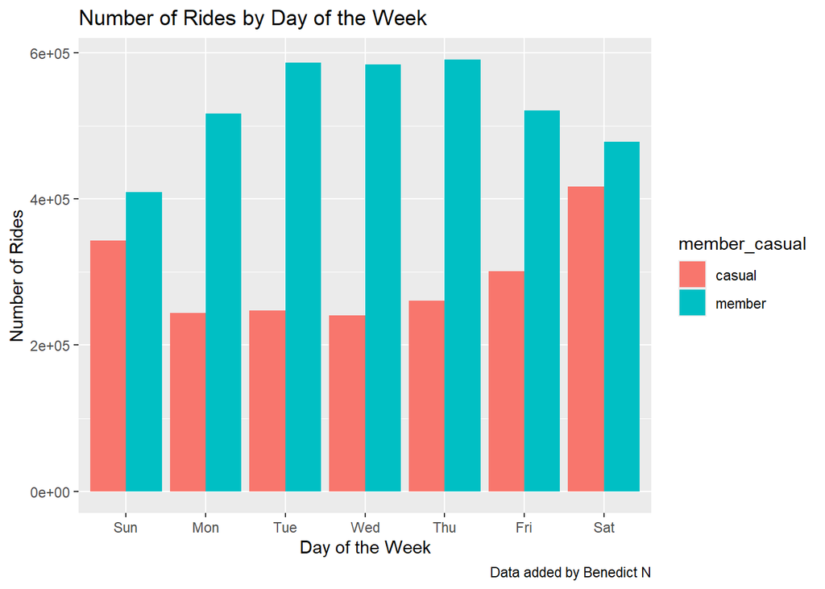

```r
combined_df %>%
    count(day_of_week, member_casual) %>%
    ggplot(aes(x = day_of_week, y = n, fill = member_casual)) +
    geom_col(position = "dodge") +
    labs(title = "Number of Rides by Day of the Week",
         x = "Day of the Week",
         y = "Number of Rides",
         caption = "Data added by Benedict N")
```

### Plot average ride length by day of the week

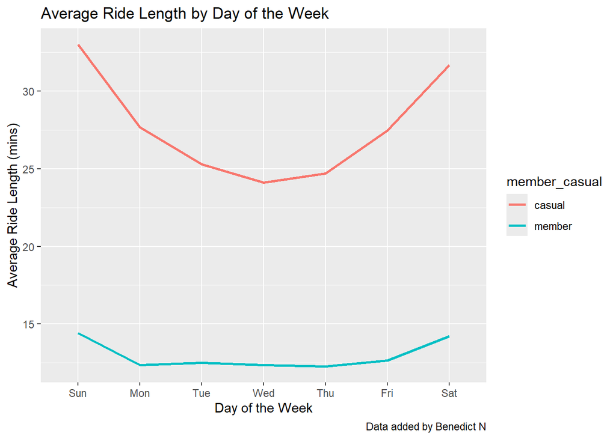

```r
combined_df %>%
    group_by(day_of_week, member_casual) %>%
    summarise(mean_ride_length = mean(ride_length)) %>%
    ggplot(aes(x = day_of_week, y = mean_ride_length, color = member_casual, group = member_casual)) +
  # Adjust group aesthetic
    geom_line(size = 1) +
    labs(title = "Average Ride Length by Day of the Week",
         x = "Day of the Week",
         y = "Average Ride Length (mins)",
         caption = "Data added by Benedict N")
```

## Summary of the analysis and Key Insights

1. Annual members tend to use Cyclistic bikes for shorter durations compared to casual riders.
2. Casual riders, on the other hand, have longer average ride lengths. This may indicate that they use the  
   bikes for leisure or recreational purposes.
3. Throughout the week there are variations in ride patterns, with different usage trends observed for  
   weekdays versus weekends.

## Recommendations

1. Target marketing campaigns on weekends when casual riders are more likely to use the service.
2. Promote benefits of membership such as cost savings for frequent riders.
3. Use digital media campaigns highlighting the convenience of annual memberships